# simon-5502-06-solution

## General directions

Use the dataset, gardasil.tsv, found on my github site. Refer to the [data dictionary](https://github.com/pmean/data/blob/main/files/gardasil.yaml) if needed. You may find it helpful to adapt some of the code from simon-5502-06-demo.qmd.

## File details

Please do not look at this file before submitting your own work on this programming assignment. Although no interpretations are provided here, you must include them in your own submission.

This program was written by Steve Simon on 2025-02-27 and is placed in the public domain. You can use this program any way you please.

This program examines some logistic regression models to predict the probability that a patient will complete all three shots in the HPV vaccination program.

```r
library(broom)
library(glue)
library(readxl)
library(tidyverse)
R.version.string
```

```
[1] "R version 4.4.3 (2025-02-28 ucrt)"
```

```r
Sys.Date()
```

```
[1] "2025-03-02"
```

## Read the data

```r
ga <- read_tsv(
  file="../data/gardasil.tsv",
  col_names=TRUE,
  col_types="n")
glimpse(ga)
```

```
Rows: 1,413
Columns: 10
$ Age           <dbl> 21, 21, 20, 14, 17, 11, 17, 15, 13, 18, 17, 22, 16, 13, …
$ AgeGroup      <dbl> 1, 1, 1, 0, 0, 0, 0, 0, 0, 1, 0, 1, 0, 0, 0, 1, 1, 1, 0,…
$ Race          <dbl> 0, 0, 0, 0, 3, 1, 0, 3, 3, 0, 1, 0, 3, 1, 1, 0, 1, 1, 0,…
$ Shots         <dbl> 3, 3, 1, 3, 2, 1, 1, 3, 3, 3, 2, 2, 1, 2, 1, 1, 1, 3, 3,…
$ Completed     <dbl> 1, 1, 0, 1, 0, 0, 0, 1, 1, 1, 0, 0, 0, 0, 0, 0, 0, 1, 1,…
$ InsuranceType <dbl> 3, 3, 1, 3, 3, 0, 3, 1, 1, 2, 1, 3, 1, 3, 0, 1, 1, 1, 1,…
$ MedAssist     <dbl> 0, 0, 0, 0, 0, 1, 0, 0, 0, 0, 0, 0, 0, 0, 1, 0, 0, 0, 0,…
$ Location      <dbl> 1, 1, 1, 1, 1, 1, 1, 1, 1, 1, 1, 1, 1, 1, 1, 1, 1, 1, 1,…
$ LocationType  <dbl> 0, 0, 0, 0, 0, 0, 0, 0, 0, 0, 0, 0, 0, 0, 0, 0, 0, 0, 0,…
$ PracticeType  <dbl> 1, 1, 1, 0, 1, 0, 1, 0, 0, 1, 0, 1, 0, 0, 0, 1, 1, 1, 1,…
```

## Question 1

You will not be graded on this, but get in the habit of computing some simple statistics (mean, standard deviation, minimum, and maximum for continuous variables and counts and percentages for categorical variables) for the important variables in this dataset. Also, get in the habit of providing brief interpretations.

## Descriptive statistics

```r
ga |>
  summarize(
    Age_mean=mean(Age),
    Age_sd=sd(Age),
    Age_min=min(Age),
    Age_max=max(Age))
```

```
# A tibble: 1 × 4
  Age_mean Age_sd Age_min Age_max
     <dbl>  <dbl>   <dbl>   <dbl>
1     18.5   4.23      11      26
```

#### Interpretation of the output

Don’t forget to put interpretations here and after every other program chunk that produces a table or graph.

```r
ga |>
    count(Completed) |>
    mutate(total=sum(n)) |>
    mutate(pct=round(100*n/total)) |>
    mutate(pct=glue("{pct}% ({n}/{total})")) |>
    select(-n, -total)
```

```
# A tibble: 2 × 2
  Completed pct
      <dbl> <glue>
1         0 67% (944/1413)
2         1 33% (469/1413)
```

```r
ga |>
    count(MedAssist) |>
    mutate(total=sum(n)) |>
    mutate(pct=round(100*n/total)) |>
    mutate(pct=glue("{pct}% ({n}/{total})")) |>
    select(-n, -total)
```

```
# A tibble: 2 × 2
  MedAssist pct
      <dbl> <glue>
1         0 81% (1138/1413)
2         1 19% (275/1413)
```

## Question 2

Create factors with descriptive levels for Completed, MedAssist, and LocationType. Orient your factor so that the reference category (the category that appears first) is “No” for Completed and MedAssist and “Urban” for LocationType. Calculate the probability of completing all three shorts for each level of MedAssist. Repeat for each level of LocationType.

```r
lab1 <- c("No", "Yes")
lab2 <- c("Urban", "Suburban")

ga |>
  mutate(
    Completed =
      factor(
        Completed,
        levels=0:1,
        labels=lab1)) |>
  mutate(
    MedAssist =
      factor(
        MedAssist,
        levels=0:1,
        labels=lab1)) |>
  mutate(
    LocationType =
      factor(
        LocationType,
        levels=1:0,
        labels=lab2))-> ga_1
```

## Completion probabilities for MedAssist

```r
ga_1 |>
    count(MedAssist, Completed) |>
  group_by(MedAssist) |>
    mutate(total=sum(n)) |>
    mutate(pct=round(100*n/total)) |>
    mutate(pct=glue("{pct}% ({n}/{total})")) |>
  filter(Completed=="Yes") |>
    select(-n, -total)
```

```
# A tibble: 2 × 3
# Groups:   MedAssist [2]
  MedAssist Completed pct
  <fct>     <fct>     <glue>
1 No        Yes       36% (414/1138)
2 Yes       Yes       20% (55/275)
```

## Completion probabilities for LocationType

```r
ga_1 |>
    count(LocationType, Completed) |>
  group_by(LocationType) |>
    mutate(total=sum(n)) |>
    mutate(pct=round(100*n/total)) |>
    mutate(pct=glue("{pct}% ({n}/{total})")) |>
  filter(Completed=="Yes") |>
    select(-n, -total)
```

```
# A tibble: 2 × 3
# Groups:   LocationType [2]
  LocationType Completed pct
  <fct>        <fct>     <glue>
1 Urban        Yes       25% (114/450)
2 Suburban     Yes       37% (355/963)
```

## Question 3

Calculate a logistic regression model using Age (not AgeGroup) to predict whether a patient has completed all three shots. Interpret the odds ratio from this model.

## Logistic regression models

```r
m1 <- glm(
  Completed~Age,
  family=binomial,
  data=ga_1)
```

## Display Age coefficient

```r
m1 |>
  tidy() |>
  mutate(
    p.value =
      case_when(
        p.value >= 0.001 ~ glue("p = {round(p.value, 3)}"),
        p.value <  0.001 ~ "p < 0.001")) -> m1_betas
m1_betas
```

```
# A tibble: 2 × 5
  term        estimate std.error statistic p.value
  <chr>          <dbl>     <dbl>     <dbl> <glue>
1 (Intercept)  -0.334     0.253      -1.32 p = 0.187
2 Age          -0.0198    0.0134     -1.47 p = 0.14
```

```r
m1_betas |>
  filter(term != "(Intercept)") |>
  mutate(odds_ratio=exp(estimate)) |>
  mutate(lower=exp(estimate+qnorm(0.025)*std.error)) |>
  mutate(upper=exp(estimate+qnorm(0.975)*std.error)) |>
  select(term, odds_ratio, lower, upper) -> m1_or
m1_or
```

```
# A tibble: 1 × 4
  term  odds_ratio lower upper
  <chr>      <dbl> <dbl> <dbl>
1 Age        0.980 0.955  1.01
```

## Question 4

You suspect that there is an interaction between MedAssist and LocationType in predicting whether a patient completed all three shots. Draw a line plot on the log odds scale. Interpret this plot. You should look at the plot two different ways, but please only include one plot here.

Note: some versions of R may need to use trans=“logit” instead of transform=“logit” in the scale_y_continuous function.

```r
ga_1 |>
    count(MedAssist, LocationType, Completed) |>
    group_by(MedAssist, LocationType) |>
    mutate(total=sum(n)) |>
    mutate(prop=n/total) -> table1

table1
```

```
# A tibble: 8 × 6
# Groups:   MedAssist, LocationType [4]
  MedAssist LocationType Completed     n total  prop
  <fct>     <fct>        <fct>     <int> <int> <dbl>
1 No        Urban        No          149   213 0.700
2 No        Urban        Yes          64   213 0.300
3 No        Suburban     No          575   925 0.622
4 No        Suburban     Yes         350   925 0.378
5 Yes       Urban        No          187   237 0.789
6 Yes       Urban        Yes          50   237 0.211
7 Yes       Suburban     No           33    38 0.868
8 Yes       Suburban     Yes           5    38 0.132
```

## Interaction plot

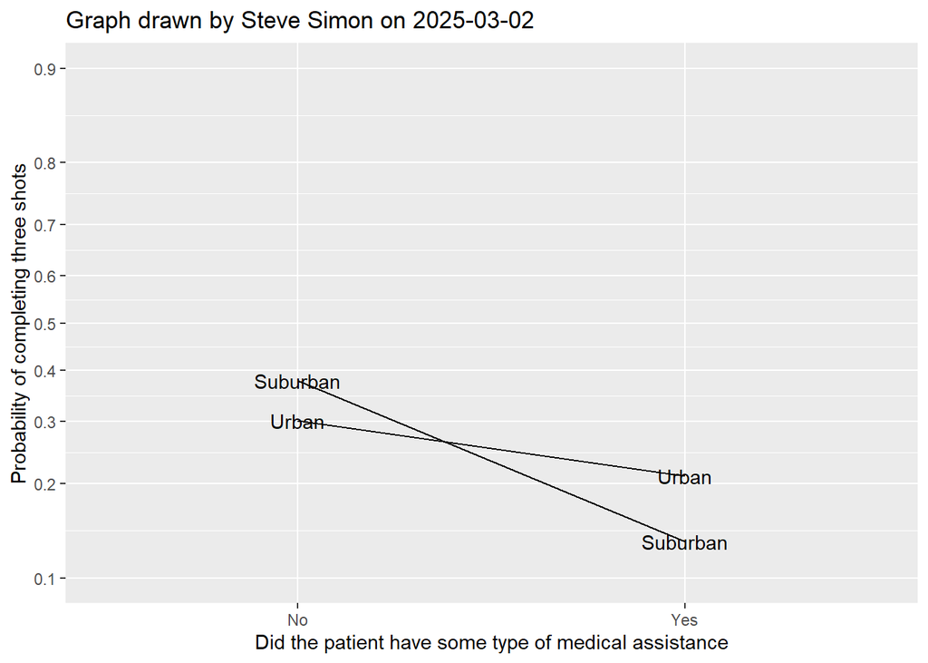

```r
table1 |>
    filter(Completed=="Yes") |>
    ggplot() +
  aes(x=MedAssist, y=prop) +
  geom_line(aes(group=LocationType)) +
  geom_text(aes(label=LocationType)) +
    expand_limits(y=c(0.1, 0.9)) +
  ggtitle("Graph drawn by Steve Simon on 2025-03-02") +
  xlab("Did the patient have some type of medical assistance") +
  ylab("Probability of completing three shots") -> lines_1
lines_1 +
    scale_y_continuous(breaks=(1:9)/10, transform="logit")
```

## Question 5

Fit a model using MedAssist and LocationType to predict Completed, first without an interaction and then with an interaction. Test whether the interaction is statistically significant.

## Fitting models without and with interaction

```r
m2 <- glm(
  Completed~MedAssist+LocationType,
  family=binomial,
  data=ga_1)

m3 <- glm(
  Completed~MedAssist*LocationType,
  family=binomial,
  data=ga_1)
```

## Two approaches. You should present one or the other but not both

## Testing interaction (first approach)

```r
anova(m2, m3)
```

```
Analysis of Deviance Table

Model 1: Completed ~ MedAssist + LocationType
Model 2: Completed ~ MedAssist * LocationType
  Resid. Df Resid. Dev Df Deviance Pr(>Chi)
1      1410     1764.7
2      1409     1761.2  1   3.4068  0.06493 .
---
Signif. codes:  0 '***' 0.001 '**' 0.01 '*' 0.05 '.' 0.1 ' ' 1
```

## Testing interaction (second approach) Note that only one is needed

```r
m3 |>
  tidy() |>
  mutate(
    p.value =
      case_when(
        p.value >= 0.001 ~ glue("p = {round(p.value, 3)}"),
        p.value <  0.001 ~ "p < 0.001")) -> m3_betas
m3_betas
```

```
# A tibble: 4 × 5
  term                              estimate std.error statistic p.value
  <chr>                                <dbl>     <dbl>     <dbl> <glue>
1 (Intercept)                         -0.845     0.149     -5.65 p < 0.001
2 MedAssistYes                        -0.474     0.218     -2.17 p = 0.03
3 LocationTypeSuburban                 0.349     0.164      2.12 p = 0.034
4 MedAssistYes:LocationTypeSuburban   -0.917     0.532     -1.72 p = 0.085
```